# Assignment 7 Text Analysis

#### Assignment 7

Text Analytics

1. Extract Sample document and apply following document preprocessing methods: Tokenization, POS Tagging, stop words removal, Stemming and Lemmatization.
2. Create representation of document by calculating Term Frequency and Inverse Document Frequency. Provide the codes with outputs and explain everything that you do in this step.

### Assignment 7

## Import Libraries

```python
#!pip install Document
```

```python
#!pip install spacy
#!python -m spacy download Lemmatizer


#!pip install docx
#!pip install python-docx
#!pip install -U spacy

#!python -m spacy download en_core_web_sm
```

```python
import numpy as np
import pandas as pd
import matplotlib.pyplot as plt
%matplotlib inline
import seaborn as sns
from sklearn.preprocessing import LabelEncoder
import spacy
nlp = spacy.load('en_core_web_sm')
import document
from docx import Document
import warnings
warnings.filterwarnings('ignore')
import docx2txt
```

## Load and review data

```python
path = 'testdoc.docx'
text = docx2txt.process(path)
#print(text)
path2 = 'testdoc2.docx'
text2 = docx2txt.process(path2)
#print(text2)
```

```python
doc = nlp(text)
# Extract tokens for the given doc
print ([token.text for token in doc])
print(len(doc))
doc2 = nlp(text2)
print(len(text2))
corpus = [doc,doc2]
```

```
['Millions', 'of', 'people', 'in', 'India', 'took', 'part', 'in', 'an', 'annual', 'tree', 'planting', 'drive', 'Sunday', '.', 'More', 'than', '250', 'million', 'saplings', 'were', 'planted', 'in', 'a', 'single', 'day', 'across', 'the', 'country', "'s", 'most', '-', 'populous', 'state', '.', '\n\n', …
462
3790
```

```python
sentences = list(doc.sents)
print(len(sentences))
```

```
21
```

```python
for token in doc:
     print ("\n",token, token.idx, token.text_with_ws,
            token.is_alpha, token.is_punct, token.is_space,
            token.shape_, token.is_stop)
```

```
 Millions 0 Millions  True False False Xxxxx False

 of 9 of  True False False xx True

 people 12 people  True False False xxxx False

 in 19 in  True False False xx True

 India 22 India  True False False Xxxxx False

 took 28 took  True False False xxxx False

 part 33 part  True False False xxxx True

 in 38 in  True False False xx True

 an 41 an  True False False xx True

 annual 44 annual  True False False xxxx False

 tree 51 tree  True False False xxxx False

 planting 56 planting  True False False xxxx False

 drive 65 drive  True False False xxxx False

 Sunday 71 Sunday True False False Xxxxx False

 . 77 .  False True False . False

 More 79 More  True False False Xxxx True

 than 84 than  True False False xxxx True

 250 89 250  False False False ddd False

 million 93 million  True False False xxxx False

 saplings 101 saplings  True False False xxxx False

```

[output cut: 964 more lines]

```
 has 2224 has  True False False xxx True

 put 2228 put  True False False xxx True

 further 2232 further  True False False xxxx True

 stress 2240 stress  True False False xxxx False

 on 2247 on  True False False xx True

 the 2250 the  True False False xxx True

 land 2254 land True False False xxxx False

 . 2258 . False True False . False
```

```python
spacy_stopwords = spacy.lang.en.stop_words.STOP_WORDS

len(spacy_stopwords)
```

```
326
```

```python
words = [word.lemma_ for word in doc]
print(words)
```

```
['million', 'of', 'people', 'in', 'India', 'take', 'part', 'in', 'an', 'annual', 'tree', 'planting', 'drive', 'Sunday', '.', 'More', 'than', '250', 'million', 'sapling', 'be', 'plant', 'in', 'a', 'single', 'day', 'across', 'the', 'country', "'s", 'most', '-', 'populous', 'state', '.', '\n\n', 'the',…
```

```python
vocabulary = []
vocabulary =  " ".join([word.lemma_ for word in doc if word not in spacy_stopwords])
print(vocabulary)
```

```
million of people in India take part in an annual tree planting drive Sunday . More than 250 million sapling be plant in a single day across the country 's most - populous state .

 the campaign be lead by Uttar Pradesh state government official , lawmaker , and activist , in a bid to reduce carbon emission and combat climate change .

 where be the tree plant ?

 the sapling be plant by volunteer in forest , farm , school , and along riverbank and highway .

 " we be committed to increase the forest cover of Uttar Pradesh to over 15 % of the total land area in the next five year , '' say state forest official Manoj Singh .

 accord to another government official , the forest cover of the state have increase over the last few year .

 " there have be an increase of 127 sqare kilometer [ 79 sqare mile ]   in the forest cover in Uttar Pradesh as compare to 2017 , " a state government spokesperson be quote as say in   the Indian Express newspaper .

 " there have also be an increase in tree and plant . the tree cover have increase to 3.05 % , as compare to the national average of 2.89 % , " the official say , cite the 2019 Forest Survey of India report .

 how many sapling survive ?

 Uttar Pradesh State Forest Minister Dara Singh say the long - term survival of the sapling remain a concern , add that usually only 60 % of the sapling survive . the rest succumb to disease or lack of water .

 however , he say that   about 80 % of the sapling plant in the last four annual drive have survive .

 " all the region where plantation be be carry out have be geo - tag so that we can ascertain what exactly happen , " Chauhan tell the Pioneer newspaper .

 " these sapling carry qr code so that official can maintain a record and verify whether the sapling survive or not . besides , team have be form to monitor progress of the plantation drive , " he say .

 what be the extent of India 's tree planting project ?

 India have vow to have a third of its total land area , or 95 million hectare , under forest and tree cover by 2030 .

 the government have allocate $ 6.2 billion ( € 5.2 billion ) for the tree - planting across the country .

 however , industrial development and a rapidly grow population have put further stress on the land .
```

```python
for token in doc:
    print(token, token.pos_)
```

```
Millions NOUN
of ADP
people NOUN
in ADP
India PROPN
took VERB
part NOUN
in ADP
an DET
annual ADJ
tree NOUN
planting NOUN
drive NOUN
Sunday PROPN
. PUNCT
More ADJ
than ADP
250 NUM
million NUM
saplings NOUN
were AUX
planted VERB
in ADP
a DET
single ADJ
day NOUN
across ADP
the DET
country NOUN
's PART
most ADV
- PUNCT
populous ADJ
state NOUN
. PUNCT


 SPACE
The DET
campaign NOUN
```

[output cut: 439 more lines]

```
industrial ADJ
development NOUN
and CCONJ
a DET
rapidly ADV
growing VERB
population NOUN
has AUX
put VERB
further ADJ
stress NOUN
on ADP
the DET
land NOUN
. PUNCT
```

```python
verbs = [token.text for token in doc if token.pos_ == "VERB"]
nouns = [token.text for token in doc if token.pos_ == "NOUN"]
print('Verbs ',len(verbs),'Nouns ',len(nouns))
print('Verbs ',verbs)
```

```
Verbs  43 Nouns  113
Verbs  ['took', 'planted', 'led', 'reduce', 'planted', 'planted', 'increasing', 'said', 'According', 'increased', 'compared', 'quoted', 'saying', 'increased', 'compared', 'said', 'citing', 'survive', 'said', 'remains', 'adding', 'survive', 'disease', 'said', 'planted', 'survived', 'carried', 'tagged…
```

```python
for token in doc:
    print(token, token.lemma_)
```

```
Millions million
of of
people people
in in
India India
took take
part part
in in
an an
annual annual
tree tree
planting planting
drive drive
Sunday Sunday
. .
More More
than than
250 250
million million
saplings sapling
were be
planted plant
in in
a a
single single
day day
across across
the the
country country
's 's
most most
- -
populous populous
state state
. .





```

[output cut: 471 more lines]

```
industrial industrial
development development
and and
a a
rapidly rapidly
growing grow
population population
has have
put put
further further
stress stress
on on
the the
land land
. .
```

```python
import nltk
from nltk.stem import WordNetLemmatizer,PorterStemmer
```

```python
words = []

words = " ".join(token.text for token in doc)
words
```

```
'Millions of people in India took part in an annual tree planting drive Sunday . More than 250 million saplings were planted in a single day across the country \'s most - populous state . \n\n The campaign was led by Uttar Pradesh state government officials , lawmakers , and activists , in a bid to …
```

```python
ps = PorterStemmer()
stemmed_words = []
for token in doc:
    stemmed_words.append(ps.stem(token.text))
```

```python
stemmed_words
```

```
['million',
 'of',
 'peopl',
 'in',
 'india',
 'took',
 'part',
 'in',
 'an',
 'annual',
 'tree',
 'plant',
 'drive',
 'sunday',
 '.',
 'more',
 'than',
 '250',
 'million',
 'sapl',
 'were',
 'plant',
 'in',
 'a',
 'singl',
 'day',
 'across',
 'the',
 'countri',
 "'s",
 'most',
 '-',
 'popul',
 'state',
 '.',
 '\n\n',
 'the',
 'campaign',
 'wa',
 'led',
```

[output cut: 407 more lines]

```
 'industri',
 'develop',
 'and',
 'a',
 'rapidli',
 'grow',
 'popul',
 'ha',
 'put',
 'further',
 'stress',
 'on',
 'the',
 'land',
 '.']
```

```python
wl = WordNetLemmatizer()
wl_stemmed_words = []
for token in doc:
    wl_stemmed_words.append(wl.lemmatize(token.text))
wl_stemmed_words
```

```
['Millions',
 'of',
 'people',
 'in',
 'India',
 'took',
 'part',
 'in',
 'an',
 'annual',
 'tree',
 'planting',
 'drive',
 'Sunday',
 '.',
 'More',
 'than',
 '250',
 'million',
 'sapling',
 'were',
 'planted',
 'in',
 'a',
 'single',
 'day',
 'across',
 'the',
 'country',
 "'s",
 'most',
 '-',
 'populous',
 'state',
 '.',
 '\n\n',
 'The',
 'campaign',
 'wa',
 'led',
```

[output cut: 407 more lines]

```
 'industrial',
 'development',
 'and',
 'a',
 'rapidly',
 'growing',
 'population',
 'ha',
 'put',
 'further',
 'stress',
 'on',
 'the',
 'land',
 '.']
```

```python
corpus = [text,text2]
def termfreq(corpus):
    dic={}

    for doc in corpus:
        #words = " ".join([token.text for token in doc])
        for word in doc.split():
            if word in dic:
                dic[word]+=1
            else:
                dic[word]=1

    for word,freq in dic.items():
        print(word,freq)
        dic[word]=freq/len(doc)
    print('Document size in number of words',len(doc))
    return dic
termfreq(corpus)
```

```
Millions 1
of 36
people 1
in 22
India 3
took 1
part 2
an 4
annual 2
tree 6
planting 5
drive 5
Sunday. 1
More 1
than 1
250 1
million 2
saplings 14
were 6
planted 7
a 15
single 2
day 1
across 3
the 64
country's 1
most-populous 1
state. 1
The 12
campaign 1
was 6
led 1
by 5
Uttar 4
Pradesh 4
state 6
government 8
officials, 1
lawmakers, 1
and 26
```

[output cut: 419 more lines]

```
Green 1
Army 1
website 1
www.greenarmy.mahaforest.gov.in 1
An 1
integrated 1
place 1
ensure 1
seamless 1
successful 1
participation 1
society, 1
especially 1
public. 1
Document size in number of words 3790
```

```
{'Millions': 0.0002638522427440633,
 'of': 0.00949868073878628,
 'people': 0.0002638522427440633,
 'in': 0.005804749340369393,
 'India': 0.0007915567282321899,
 'took': 0.0002638522427440633,
 'part': 0.0005277044854881266,
 'an': 0.0010554089709762533,
 'annual': 0.0005277044854881266,
 'tree': 0.0015831134564643799,
 'planting': 0.0013192612137203166,
 'drive': 0.0013192612137203166,
 'Sunday.': 0.0002638522427440633,
 'More': 0.0002638522427440633,
 'than': 0.0002638522427440633,
 '250': 0.0002638522427440633,
 'million': 0.0005277044854881266,
 'saplings': 0.0036939313984168864,
 'were': 0.0015831134564643799,
 'planted': 0.0018469656992084432,
 'a': 0.00395778364116095,
 'single': 0.0005277044854881266,
 'day': 0.0002638522427440633,
 'across': 0.0007915567282321899,
 'the': 0.016886543535620052,
 "country's": 0.0002638522427440633,
 'most-populous': 0.0002638522427440633,
 'state.': 0.0002638522427440633,
 'The': 0.0031662269129287598,
 'campaign': 0.0002638522427440633,
 'was': 0.0015831134564643799,
 'led': 0.0002638522427440633,
 'by': 0.0013192612137203166,
 'Uttar': 0.0010554089709762533,
 'Pradesh': 0.0010554089709762533,
 'state': 0.0015831134564643799,
 'government': 0.0021108179419525065,
 'officials,': 0.0002638522427440633,
 'lawmakers,': 0.0002638522427440633,
 'and': 0.006860158311345646,
```

[output cut: 418 more lines]

```
 'register': 0.0002638522427440633,
 'Green': 0.0002638522427440633,
 'Army': 0.0002638522427440633,
 'website': 0.0002638522427440633,
 'www.greenarmy.mahaforest.gov.in': 0.0002638522427440633,
 'An': 0.0002638522427440633,
 'integrated': 0.0002638522427440633,
 'place': 0.0002638522427440633,
 'ensure': 0.0002638522427440633,
 'seamless': 0.0002638522427440633,
 'successful': 0.0002638522427440633,
 'participation': 0.0002638522427440633,
 'society,': 0.0002638522427440633,
 'especially': 0.0002638522427440633,
 'public.': 0.0002638522427440633}
```

```python
#print(text)
```

```python
#print(text2)
```

### IDF

TF-IDF stands for “Term Frequency — Inverse Data Frequency”. First, we will learn what this term means mathematically.

Term Frequency (tf): gives us the frequency of the word in each document in the corpus. It is the ratio of number of times the word appears in a document compared to the total number of words in that document. It increases as the number of occurrences of that word within the document increases. Each document has its own tf.

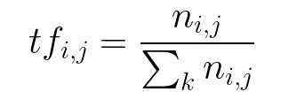

Inverse Data Frequency (idf): used to calculate the weight of rare words across all documents in the corpus. The words that occur rarely in the corpus have a high IDF score. It is given by the equation below.

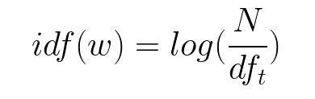

Combining these two we come up with the TF-IDF score (w) for a word in a document in the corpus. It is the product of tf and idf:

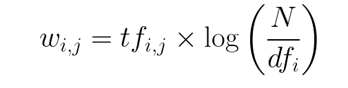

```python
import re
import nltk
from nltk.corpus import stopwords
doc_text = " "

def preprocess_docs(text):
    text = str(text).lower()
    #print(text)
    text = re.sub('[^a-zA-z0-9\s]','',str(text))
    text = text.split()
    #print(text)
    text = [wl.lemmatize(word) for word in text if not word in stopwords.words('english')]
    new_text = ' '.join(text)
    #print("\ndoc : ", new_text)
        #doc_text = doc_text + new_text
            #doc_text = doc_text + new_text
        #print(new_text)
    return new_text
corpus = [text,text2]
#print(text)
text1 = preprocess_docs(text)
text2 = preprocess_docs(text2)
print("\n doc1",text1,"\nDoc 2",text2)
```

```
 doc1 million people india took part annual tree planting drive sunday 250 million sapling planted single day across country mostpopulous state campaign led uttar pradesh state government official lawmaker activist bid reduce carbon emission combat climate change tree planted sapling planted volunte…
Doc 2 2016 2019 state forest department bjp government launched green maharashtra drive aim plant 50 crore tree across state fouryear period october 2019 government claimed surpassed target planting 33 crore tree julyseptember 2019 indian express found nonforest agency gram panchayat tasked planting…
```

```python
first= text1
second= text2
#split so each word have their own string
first = first.split(" ")
second= second.split(" ")
#print(first,second)
total= set(first).union(set(second))
#print(total)
wordDictA = dict.fromkeys(total, 0)
wordDictB = dict.fromkeys(total, 0)
for word in first:
    wordDictA[word]+=1

for word in second:
    wordDictB[word]+=1
#put them in a dataframe and then view the result:
pd.DataFrame([wordDictA, wordDictB])
```

|  | 15 | forest | celebrate | citing | many | agency | planting | six | 62 | operational | ... | resounding | mobile | 59 | namely | ncc | statewide | geotagged | carry | target | pune |
| --- | --- | --- | --- | --- | --- | --- | --- | --- | --- | --- | --- | --- | --- | --- | --- | --- | --- | --- | --- | --- | --- |
| 0 | 1 | 8 | 0 | 1 | 1 | 0 | 2 | 0 | 1 | 0 | ... | 0 | 0 | 0 | 0 | 0 | 0 | 1 | 1 | 0 | 0 |
| 1 | 0 | 13 | 1 | 0 | 1 | 2 | 3 | 1 | 0 | 1 | ... | 1 | 1 | 1 | 1 | 1 | 1 | 0 | 0 | 4 | 5 |

2 rows × 321 columns

```python
def computeTF(wordDict, bow):
    tfDict = {}
    bowCount = len(bow)
    for word, count in wordDict.items():
        tfDict[word] = count/float(bowCount)
    return tfDict
#running our sentences through the tf function:
tfFirst = computeTF(wordDictA, first)
tfSecond = computeTF(wordDictB, second)
#Converting to dataframe for visualization
tf_df= pd.DataFrame([tfFirst, tfSecond])
tf_df.head()
```

|  | 15 | forest | celebrate | citing | many | agency | planting | six | 62 | operational | ... | resounding | mobile | 59 | namely | ncc | statewide | geotagged | carry | target | pune |
| --- | --- | --- | --- | --- | --- | --- | --- | --- | --- | --- | --- | --- | --- | --- | --- | --- | --- | --- | --- | --- | --- |
| 0 | 0.004566 | 0.036530 | 0.000000 | 0.004566 | 0.004566 | 0.00000 | 0.009132 | 0.000000 | 0.004566 | 0.000000 | ... | 0.000000 | 0.000000 | 0.000000 | 0.000000 | 0.000000 | 0.000000 | 0.004566 | 0.004566 | 0.000000 | 0.000000 |
| 1 | 0.000000 | 0.035422 | 0.002725 | 0.000000 | 0.002725 | 0.00545 | 0.008174 | 0.002725 | 0.000000 | 0.002725 | ... | 0.002725 | 0.002725 | 0.002725 | 0.002725 | 0.002725 | 0.002725 | 0.000000 | 0.000000 | 0.010899 | 0.013624 |

2 rows × 321 columns

```python
def computeIDF(docList):
    idfDict = {}
    N = len(docList)

    idfDict = dict.fromkeys(docList[0].keys(), 0)
    for doc in docList:
        for word, val in doc.items():
            if val > 0:
                idfDict[word] += 1

    for word, val in idfDict.items():
        idfDict[word] = math.log10(N / float(val))

    return idfDict
#inputing our sentences in the log file
idfs = computeIDF([wordDictA, wordDictB])
```

```python
idfs
```

```
{'15': 0.3010299956639812,
 'forest': 0.0,
 'celebrate': 0.3010299956639812,
 'citing': 0.3010299956639812,
 'many': 0.0,
 'agency': 0.3010299956639812,
 'planting': 0.0,
 'six': 0.3010299956639812,
 '62': 0.3010299956639812,
 'operational': 0.3010299956639812,
 'dedicated': 0.3010299956639812,
 'figure': 0.3010299956639812,
 'allocated': 0.3010299956639812,
 'sapling': 0.0,
 'department': 0.3010299956639812,
 'body': 0.3010299956639812,
 'mulshi': 0.3010299956639812,
 'teakwood': 0.3010299956639812,
 'division': 0.3010299956639812,
 'crore': 0.3010299956639812,
 'bjp': 0.3010299956639812,
 'district': 0.3010299956639812,
 'unavailability': 0.3010299956639812,
 'sqare': 0.3010299956639812,
 'uploaded': 0.3010299956639812,
 'consecutive': 0.3010299956639812,
 'kilometer': 0.3010299956639812,
 'mandatory': 0.3010299956639812,
 'exactly': 0.3010299956639812,
 'free': 0.3010299956639812,
 'consistency': 0.3010299956639812,
 'record': 0.0,
 'individual': 0.3010299956639812,
 'created': 0.3010299956639812,
 'place': 0.3010299956639812,
 'hectare': 0.3010299956639812,
 '2017': 0.0,
 'planned': 0.3010299956639812,
 'circle': 0.3010299956639812,
 'detail': 0.3010299956639812,
```

[output cut: 266 more lines]

```
 'nonforest': 0.3010299956639812,
 'system': 0.3010299956639812,
 'india': 0.3010299956639812,
 'rapidly': 0.3010299956639812,
 'indapur': 0.3010299956639812,
 'resounding': 0.3010299956639812,
 'mobile': 0.3010299956639812,
 '59': 0.3010299956639812,
 'namely': 0.3010299956639812,
 'ncc': 0.3010299956639812,
 'statewide': 0.3010299956639812,
 'geotagged': 0.3010299956639812,
 'carry': 0.3010299956639812,
 'target': 0.3010299956639812,
 'pune': 0.3010299956639812}
```

```python
def computeTFIDF(tfBow, idfs):
    tfidf = {}
    for word, val in tfBow.items():
        tfidf[word] = val*idfs[word]
    return tfidf
#running our two sentences through the IDF:
idfFirst = computeTFIDF(tfFirst, idfs)
idfSecond = computeTFIDF(tfSecond, idfs)
#putting it in a dataframe
idf= pd.DataFrame([idfFirst, idfSecond])
```

```python
idf.transpose()
```

|  | 0 | 1 |
| --- | --- | --- |
| 15 | 0.001375 | 0.000000 |
| forest | 0.000000 | 0.000000 |
| celebrate | 0.000000 | 0.000820 |
| citing | 0.001375 | 0.000000 |
| many | 0.000000 | 0.000000 |
| ... | ... | ... |
| statewide | 0.000000 | 0.000820 |
| geotagged | 0.001375 | 0.000000 |
| carry | 0.001375 | 0.000000 |
| target | 0.000000 | 0.003281 |
| pune | 0.000000 | 0.004101 |

321 rows × 2 columns